# econ2200Ch02 slides

[figure not shown]

## ECON2200H

### Introduction to Statistics for Economics and Management

### 2020 Winter Term

### Week 02: Describing Data, I

#### 6 January 2020

## Outline

- Frequency table for qualitative data
- Frequency distribution for quantitative data
- Stem-and-leaf display (for small data samples)

## 1. Frequency table

- A **frequency table** is a grouping of *qualitative* data into mutually exclusive (distinctive) classes showing the number of observations in each class.
- The number of observations in each class is called the **class frequency**.
- Example: A frequency table for real estate listings in Halifax by the dwelling type.

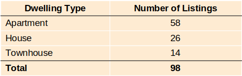

- Class frequencies can be converted to **relative class frequencies**, i.e., the number of observations in each class as a fraction of total number of observations.
- A **relative frequency** captures the relationship between a class total and the total number of observations.

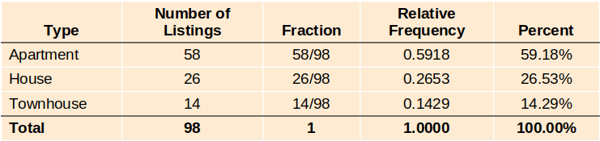

### Graphing frequencies

- A **bar** chart shows a frequency table using a series of uniformly wide rectangles.
  - The horizontal axis shows the classes corresponding to the variable of interest.
  - The vertical axis shows the frequency or relative frequency of each of the possible outcomes.
- A **pie** chart is also common in depicting qualitative information.
- A pie chart shows a frequency table using a circle that is divided into slices.
- Each slice represents the relative frequency of a class as a percentage of total number of observations.
- Bar chart for the Halifax real estate data

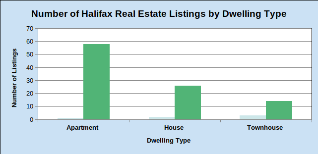

- Example of pie chart: Lottery proceeds from the Ontario Lottery and Gaming Corporation (OLG)

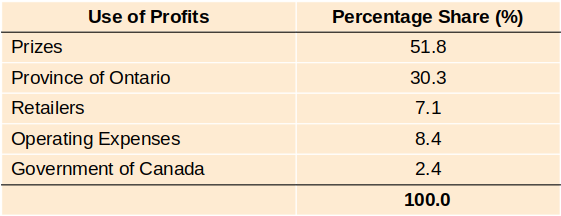

- Pie chart for OLG proceeds

[figure not shown]

- More example: Ease of navigating web pages

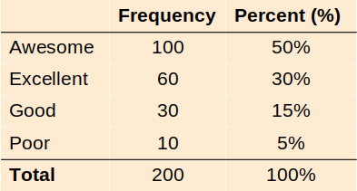

- More example: Ease of navigating web pages

[figure not shown]

- More example: Ease of navigating web pages

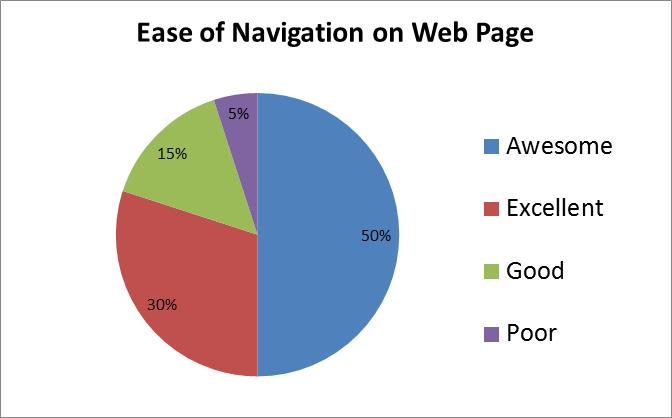

## 2. Frequency distribution

- For qualitative data, we use frequency table, for quantitative data, we can use frequency distribution.
- **Frequency distribution** is a grouping of **quantitative** data into mutually exclusive classes showing the number of observations in each class.
- Steps to construct frequency distribution:
  - Decide on the number of classes.
  - Determine the class interval or width.
  - Set the individual class limits.
  - Count the number of items in each class.

**Example**: S&P/TSX composite index list volume data for 42 days from Oct 11, 2011 to Dec 7, 2011.

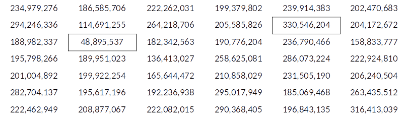

**Constructing frequency distribution**

**Step 1**, determine the number of classes.

- The number of classes ($k$) can be determined with the "2 to the k rule": select the smallest number ($k$) such that $2^k > n$, with $n$ the number of observations.
- By the rule, $k=6$ since $2^6>42$ and $2^5<42$.

**Step 2**, determine the class interval (or width).

- The class interval should be the same for all classes. Classes must cover at least the distance from the minimum value to the maximum value of observations. Let $i$ be the class interval, then $$ i \ge \frac{x_{max}- x_{min}}{k}.$$

Here, then $i \ge \frac{330,546,204 - 48,895,537}{6} = 46,941,778$. Round it to convenient numbers, $i=50,000,000.$

**Step 3**, Set the individual class limits (boundaries).

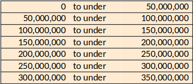

**Step 4**, count the number of observations in each class.

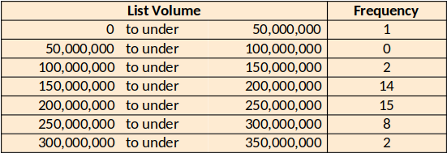

- **Class midpoint** is the value of middle spot in a class interval.

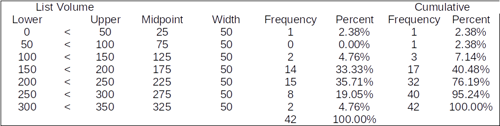

### Relative frequency distribution

- **Relative frequency distribution** converts each frequency to a relative frequency.
- To convert frequency distribution to relative frequency distribution, each class frequency is divided by total number of observations.

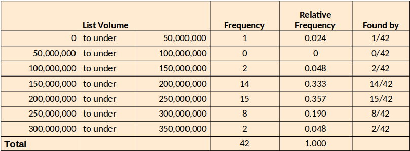

### Graphing frequency distribution

- Histogram
- Frequency polygon
- Cumulative frequency polygon

#### Histogram

- Histogram for a frequency distribution based on quantitative data is similar to a bar chart showing the distribution of qualitative data.
- Classes are marked on the horizontal axis and class frequencies on the vertical axis.
- Small difference between a histogram and a bar chart is that the bars in a histogram are drawn adjacent to each other to account for the fact that quantitative data may be continuous.

**Example**. List volume data again.

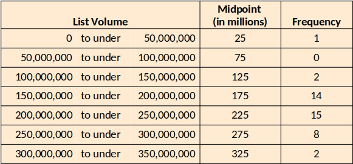

**Example**. List volume data again.

[figure not shown]

#### Findings from the histogram

1. The lowest list volume is between 0 and under 50,000,000. The highest list volume is between 300,000,000 to under 350,000,000.
2. The largest class frequency is the 200,000,000 to under 250,000,000 class. A total of 15 of the 42 volumes are within this volume range.
3. Twenty-nine of the list volume, or 69.05 percent, had a list volume in class "150,000,000 and to under 250,000,000".

#### Frequency polygon

- **Frequency polygon** shows the shape of a distribution, similar to a histogram.
- It consists of line segments connecting the points formed by the intersections of class midpoints and class frequencies.
- The midpoint of each class is scaled on the X-axis and the class frequencies on the Y-axis.
- To complete the frequency polygon, midpoints are added to both ends of the X-axis to "anchor" the polygon at zero frequency.

**Frequency polygon** for S&P/TSX list volume

[figure not shown]

#### Cumulative frequency polygon

- **Cumulative frequency distribution** shows the number of observations that fall below or above a certain value.
- There are two types of cumulative frequency distributions:
  - Less-than cumulative frequency distribution.
  - More-than cumulative frequency distribution.

**Less-than cumulative Frequency polygon** for S&P/TSX list volume

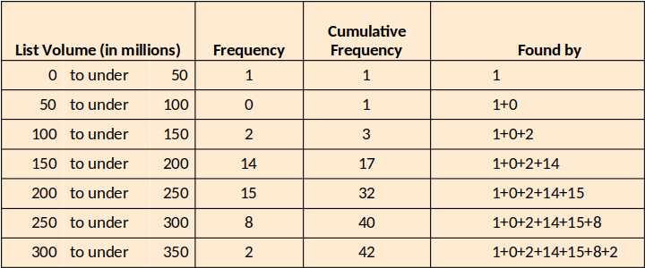

**Less-than cumulative Frequency polygon** for S&P/TSX list volume

[figure not shown]

**More-than cumulative Frequency polygon** for S&P/TSX list volume

[figure not shown]

**More-than cumulative Frequency polygon** for S&P/TSX list volume

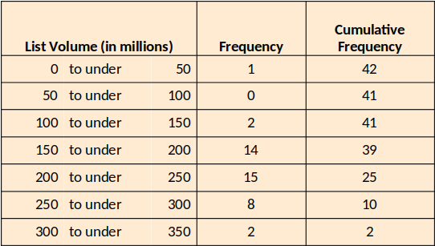

**More-than cumulative Frequency polygon** for S&P/TSX list volume

[figure not shown]

## 3. Stem-and-leaf display

- A **stem-and-leaf display** is another way of presenting quantitative data.
- Each numerical value is divided into two parts. The leading digit(s) becomes the stem and the trailing digit becomes the leaf.
- The stems are located along the vertical axis, and the leaf values are stacked against each other, in order from smallest to largest, along the horizontal axis.
- The digits themselves give a picture of the distribution.
- An advantage of the stem-and-leaf display over a frequency distribution is that we do not lose the identity of each observation.

```python
from IPython.display import HTML
HTML('''<script>
  function code_toggle() {
    if (code_shown){
      $('div.input').hide('500');
      $('#toggleButton').val('Show Code')
    } else {
      $('div.input').show('500');
      $('#toggleButton').val('Hide Code')
    }
    code_shown = !code_shown
  }

  $( document ).ready(function(){
    code_shown=false;
    $('div.input').hide()
  });
</script>
<form action="javascript:code_toggle()"><input type="submit" id="toggleButton" value="Show Code"></form>''')
```